# R Notebook

Download the file “hw8-pareto.csv” I have posted on Brightspace. For problem #1 we are just going to use the first column of this data set. The values in the first column are independent and identically distributed Pareto observations. We want to estimate the parameter a. a. Make a histogram of the values in this column.

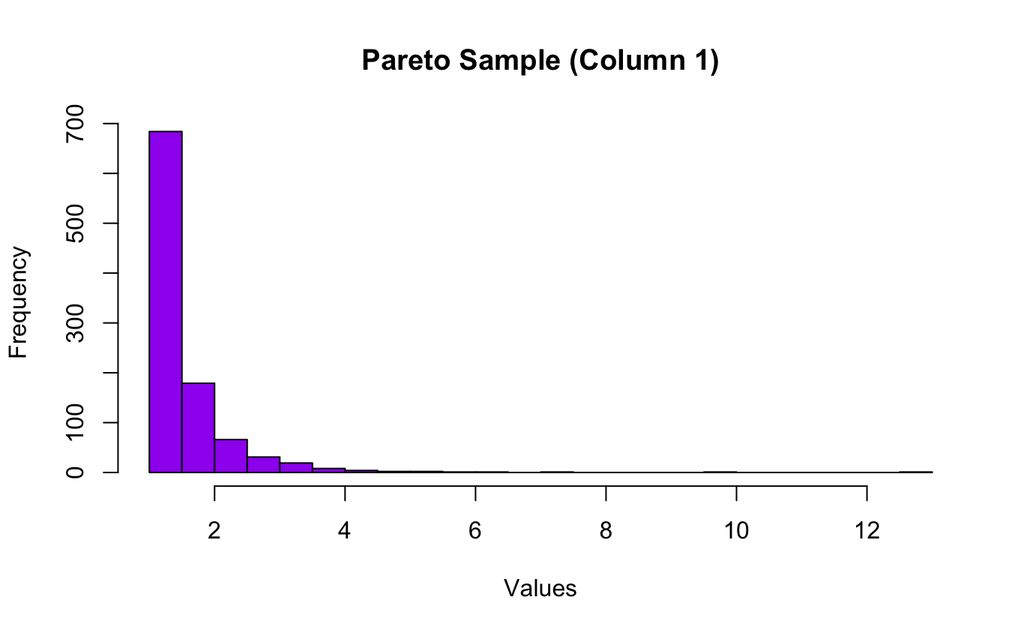

```r
# Loading the data
data <- read.csv("hw8-pareto.csv")
pareto1 <- data[[1]]
n <- length(pareto1)

# making a histogram
hist(pareto1, breaks = 30, main = "Pareto Sample (Column 1)", xlab = "Values", col = "purple", border = "black")
```

2. Compute the maximum likelihood estimator of a.

```r
# mle estimate of a
logsum <- sum(log(pareto1))
alpha_mle <- n / logsum
alpha_mle
```

```
[1] 2.972494
```

3. Compute the Fisher information I(a). Use the maximum likelihood estimator and the Fisher information to compute the 95% confidence interval for a.

```r
# Fisher info and confidence interval
fisher_info <- n / (alpha_mle^2)
std_error <- sqrt(1 / fisher_info)
z_value <- qnorm(0.975)
confint_wald <- c(alpha_mle - z_value * std_error, alpha_mle + z_value * std_error)
confint_wald
```

```
[1] 2.788261 3.156728
```

4. Compute the method of moments estimator of a.

```r
sample_mean <- mean(pareto1)
alpha_mom <- sample_mean / (sample_mean - 1)
alpha_mom
```

```
[1] 2.985278
```

5. Use the method of moments estimator and the bootstrap to compute the 95% pivotal confidence interval for a. Is the confidence interval you computed in part (c) pretty similar to the confidence interval you computed in part (e)? If not, explain why.

```r
set.seed(123)
boot_estimates <- c()

for (i in 1:1000) {
  sample_boot <- sample(pareto1, n, replace = TRUE)
  mean_boot <- mean(sample_boot)
  alpha_boot <- mean_boot / (mean_boot - 1)
  boot_estimates <- c(boot_estimates, alpha_boot)
}
confint_boot <- quantile(boot_estimates, c(0.025, 0.975))
confint_boot
```

```
    2.5%    97.5%
2.801926 3.196041
```

6. Use the Wald test to test the null hypothesis that a = 3. Compute the p-value.

```r
z_test <- (alpha_mle - 3) / std_error
pval_wald <- 2 * pnorm(-abs(z_test))
pval_wald
```

```
[1] 0.7698132
```

```r
loglik <- function(alpha, values) {
  n <- length(values)
  n * log(alpha) - alpha * sum(log(values))
}
loglik_mle <- loglik(alpha_mle, pareto1)
loglik_null <- loglik(3, pareto1)

lrt_stat <- 2 * (loglik_mle - loglik_null)
pval_lrt <- pchisq(lrt_stat, df = 1, lower.tail = FALSE)
pval_lrt
```

```
[1] 0.7704995
```

2. For problem #2 we are just going to use the second column of the data set. The values in the second column are also independent and identically distributed Pareto observations, but with a different value of a. We again want to estimate the parameter a. Repeat parts (a) – (g) from problem #1 for the second column. In parts (f) and (g) the null hypothesis is now a = 0.5.

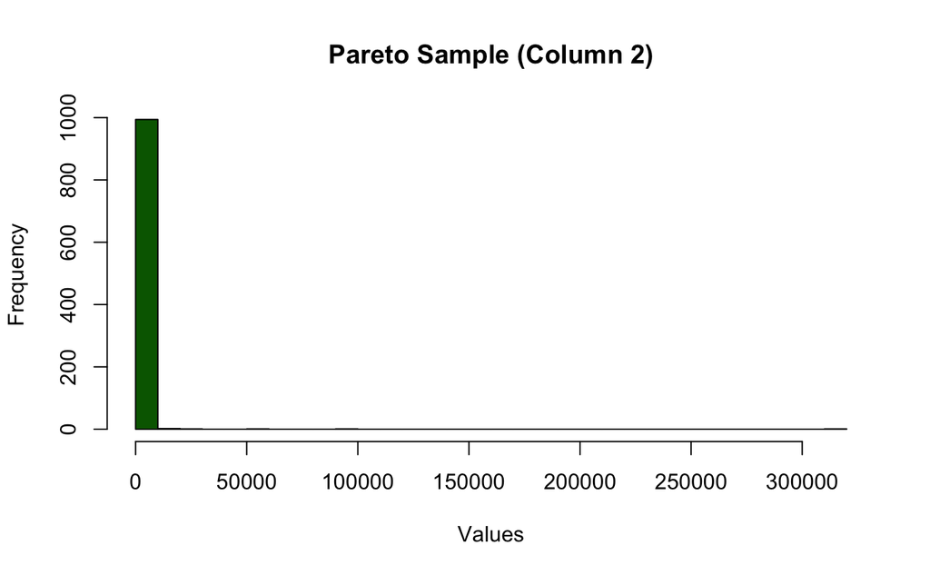

```r
# Loading the data
pareto2 <- data[[2]]
n <- length(pareto2)

# making a histogram
hist(pareto2, breaks = 30, main = "Pareto Sample (Column 2)", xlab = "Values", col = "darkgreen", border = "black")
```

```r
# mle estimate of a
logsum <- sum(log(pareto2))
alpha_mle <- n / logsum
alpha_mle
```

```
[1] 0.4933142
```

```r
# Fisher info and confidence interval
fisher_info <- n / (alpha_mle^2)
std_error <- sqrt(1 / fisher_info)
z_value <- qnorm(0.975)
confint_wald <- c(alpha_mle - z_value * std_error, alpha_mle + z_value * std_error)
confint_wald
```

```
[1] 0.4627389 0.5238896
```

```r
sample_mean <- mean(pareto2)
alpha_mom <- sample_mean / (sample_mean - 1)
alpha_mom
```

```
[1] 1.001671
```

```r
set.seed(123)
boot_estimates <- c()

for (i in 1:1000) {
  sample_boot <- sample(pareto2, n, replace = TRUE)
  mean_boot <- mean(sample_boot)
  alpha_boot <- mean_boot / (mean_boot - 1)
  boot_estimates <- c(boot_estimates, alpha_boot)
}
confint_boot <- quantile(boot_estimates, c(0.025, 0.975))
confint_boot
```

```
    2.5%    97.5%
1.000739 1.006721
```

```r
z_test <- (alpha_mle - 0.5) / std_error
pval_wald <- 2 * pnorm(-abs(z_test))
pval_wald
```

```
[1] 0.6682318
```

```r
loglik <- function(alpha, values) {
  n <- length(values)
  n * log(alpha) - alpha * sum(log(values))
}
loglik_mle <- loglik(alpha_mle, pareto2)
loglik_null <- loglik(0.5, pareto2)

lrt_stat <- 2 * (loglik_mle - loglik_null)
pval_lrt <- pchisq(lrt_stat, df = 1, lower.tail = FALSE)
pval_lrt
```

```
[1] 0.6696306
```